# 成為初級資料分析師 | 資料分析入門 SQL

> 起步走

## 郭耀仁

## 大綱

- 解決惱人的問題
- 什麼是 SQL
- SQL 的重要性
- 起步走

## 解決惱人的問題

## 身為使用者部門的工作者

- 我的需求單排序很後面...
- 資料撈回來了，但是我又想增加一些需求...
- 我不知道該怎麼跟工程師談需求...

## 可能的解法

- 找一個工程師全力支援（X）
- 申請一個資料庫帳號自己來撈資料（O）

## 這門課的目標

- 進行更有效率的需求訪談
- 提高使用者的工作掌握度
- 成為一位 power user!

## 什麼是 SQL

## SQL 是縮寫

- 發音是 **se-quel** 或者 S、Q、L
- Structured Query Language
- 查詢資料庫的語言

## 為什麼要使用資料庫？

以檔案格式存在的資料，在以下四個任務無法規模化、自動化：

- C(reate)
- R(ead)
- U(pdate)
- D(elete)

## 規模化、自動化 C(reate)：每個新註冊會員、每筆新成立訂單

## 規模化、自動化 R(ead)：發送行銷 EDM 的對象、特定節慶的折扣

## 規模化、自動化 U(pdate)：註冊會員資料的修改

## 規模化、自動化 D(elete)：會員的離開、訂單的取消

## 資料庫系統

- 商業
  - Microsoft SQL Server
  - Oracle
  - IBM DB2
  - ...etc.
- 開源
  - MySQL
  - PostgreSQL
  - MongoDB
  - ...etc.

## 另一個角度看資料庫系統分類

- SQL
  - Microsoft SQL Server
  - Oracle
  - IBM DB2
  - MySQL
  - PostgreSQL
- NoSQL
  - MongoDB
  - Firebase

## SQL 資料庫以表格的形式儲存資料

[figure not shown]

## NoSQL 資料庫以 JSON 格式儲存資料

[figure not shown]

## 資料庫系統 Pros and Cons

- 表格較直觀，但不夠靈活
- JSON 較抽象，但非常靈活

## 課堂中會使用到的 NBA 資料，以表格外觀呈現長這樣子

[figure not shown]

## 課堂中會使用到的 NBA 資料，以 JSON 外觀呈現長這樣子

[figure not shown]

## SQL 的重要性

## SQL 是在職的資料科學家推薦新手學習的前三語言之一

依據 [2017-2019 Kaggle 機器學習與資料科學調查](https://www.kaggle.com/search?q=Kaggle+ML+%26+DS+Survey)：What programming language would you recommend a new data scientist learn first?

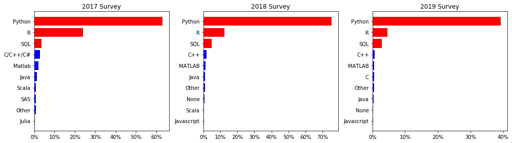

```python
plot_bar_charts([ser_2017, ser_2018, ser_2019])
```

## 沒有基本功就會...

[figure not shown]

## 起步走

## 安裝 MySQL Workbench

- 最新版本：https://dev.mysql.com/downloads/workbench/
- 較舊版本：https://downloads.mysql.com/archives/workbench/
  - 已知問題：8.0.19 在 Windows 無法打開，需要避免安裝到該版本

## 與資料庫連線的四要素

- 位址：rsqltrain.ced04jhfjfgi.ap-northeast-1.rds.amazonaws.com
- 通訊埠：3306
- 帳號：trainstudent
- 密碼：csietrain

## 新增連線

[figure not shown]

## 填寫主機位址與使用者名稱

[figure not shown]

## 開啟連線

[figure not shown]

## 輸入密碼

[figure not shown]

## 連線成功

[figure not shown]

## SELECT ALL

```
SELECT *
    FROM world.country
    LIMIT 100;
```

## Hello World!

[figure not shown]

## 觀察 world.db 其他的表格

```
SELECT *
    FROM world.city
    LIMIT 100;
```

## 觀察 nba.db 中的表格

```
SELECT *
    FROM nba.nba_teams;
```

## 觀察 tw_election_2018.db 中的表格

```
SELECT *
    FROM tw_election_2018.mayors
    LIMIT 100;
```

## 隨堂練習：從資料庫表格 `nba.player_profile` 中找出 Kawhi Leonard 的生日

[figure not shown]

```python
kawhi
```

|  | collegeName | country | dateOfBirthUTC | firstName | heightFeet | heightInches | heightMeters | isActive | jersey | lastAffiliation | lastName | nbaDebutYear | personId | pos | teamId | temporaryDisplayName | weightKilograms | weightPounds | yearsPro |
| --- | --- | --- | --- | --- | --- | --- | --- | --- | --- | --- | --- | --- | --- | --- | --- | --- | --- | --- | --- |
| 0 | San Diego State | USA | 1991-06-29 | Kawhi | 6 | 7 | 2.01 | 1 |  | San Diego State/USA | Leonard | 2011 | 202695 | F | 1610612746 | Leonard, Kawhi | 104.3 | 230 | 8 |